# Risk Prediction Model for Hospital Readmission

```r
library(tidyverse)
library(dplyr)
library(gt)
library(SmartEDA)
library(ggplot2)
library(hrbrthemes)
library(dataPreparation)
library(caret)
library(corrplot)
library(Boruta)
library(ROSE)
library(plotROC)
library(MLmetrics)
library(jtools)
library(kableExtra)
library(gridExtra)
library(glue)
```

## **1. Background**

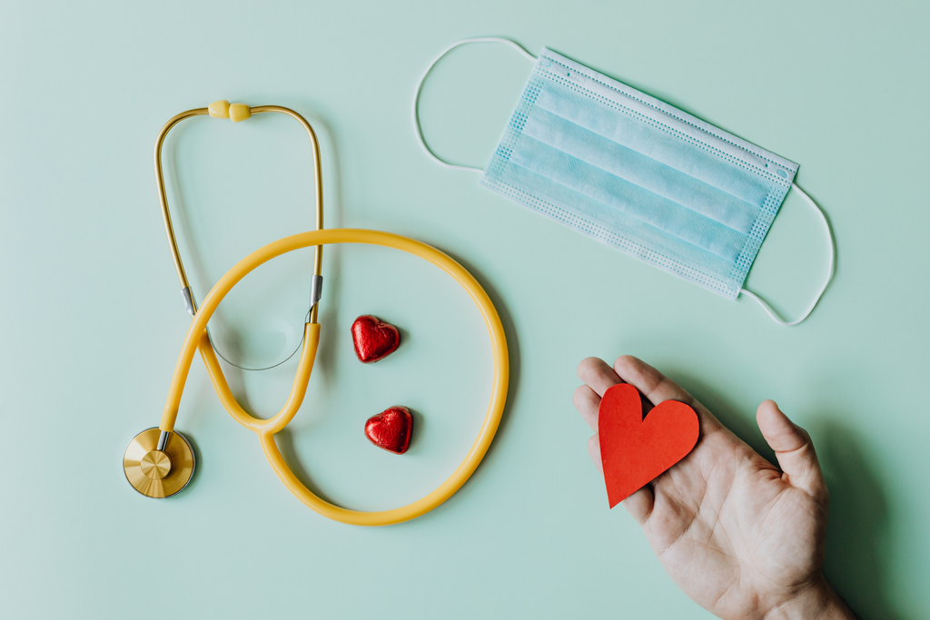

Hospital readmission costs make for a significant amount of hospital inpatient care expenses. Diabetes is not just one of the world’s top 10 leading causes of mortality, but it is also the most costly chronic disease in the United States. Diabetes patients in the hospital have a greater risk of readmission than those who do not have diabetes. As a result, lowering readmission rates for diabetes patients has the potential to considerably cut medical costs. The goal of this research is to forecast the possibility of a diabetic patient being readmitted. The dataset was collected from the University of California, Irvine’s Center for Machine Learning and Intelligent Systems and comprises over 100,000 characteristics and 50 variables such as the number of operations, drugs, and time spent in hospital etc.

## **2. Problem Statement**

Identifying which factors are the strong predictors for predicting the readmission of diabetic patients and build a classification model with good accuracy for predicting readmission.

## **3. Description of Data**

| Feature name | Type | Description and values |
| --- | --- | --- |
| encounter_id | Numeric | unique identifier of a patient visit |
| patient_nbr | Numeric | unique identifier of a patient |
| race | Categorical | values: Caucasian, Asian, African American, Hispanic, and other |
| gender | Categorical | values: male, female, and unknown/invalid |
| age | Categorical | grouped in 10-year intervals up to 100 |
| weight | Numeric | patient weight in pounds |
| admission_type_id | Categorical | integer indicating emergency, urgent, elective, newborn, and not available |
| discharge_disposition_id | Categorical | integer indicating discharged to home, expired, and not available |
| admission_source_id | Categorical | integer indicating physician referral, emergency room, and transfer from a hospital |
| time_in_hospital | Numeric | number of days between admission and discharge |
| payer_code | Categorical | Integer identifier corresponding to 23 distinct values, for example, Blue Cross\Blue Shield, Medicare, and self-pay |
| medical_specialty | Categorical | identifier of a specialty of the admitting physician, corresponding to 84 distinct values, for example, cardiology, internal medicine, family\general practice, and surgeon. |
| num_lab_procedures | Numeric | Number of lab tests performed during the encounter |
| num_procedures | Numeric | number of procedures (other than lab tests) performed |
| num_medications | Numeric | number of medications administered during the encounter |
| number_outpatient | Numeric | number of outpatient visits in the year preceding the encounter |
| number_emergency | Numeric | number of emergency visits in the year preceding the encounter |
| number_inpatient | Numeric | number of inpatient visits in the year preceding the encounter |
| diag_1 | Categorical | primary diagnosis, 848 distinct values/codes |
| diag_2 | Categorical | secondary diagnosis, 923 distinct values/codes |
| diag_3 | Categorical | additional secondary diagnosis, 954 distinct values/codes |
| number_diagnoses | Numeric | number of diagnoses entered to the system |
| max_glu_serum | Categorical | Indicates the range of the result or if the test was not taken. Values: “>200,” “>300,” “normal,” and “none” if not measured |
| A1c_result | Categorical | Indicates the range of the result or if the test was not taken. Values: “>8” if the result was greater than 8%, “>7” if the result was greater than 7% but less than 8%, “normal” if the result was less… |
| change of medications | Categorical | Indicates if there was a change in diabetic medications (either dosage or generic name). Values: “change” and “no change” |
| diabetesMed | Categorical | dichotomous indicator of diabetic medication being prescribed |
| 24 features for medications | Categorical | For the generic names: metformin, repaglinide, nateglinide, chlorpropamide, glimepiride, acetohexamide, glipizide, glyburide, tolbutamide, pioglitazone, rosiglitazone, acarbose, miglitol, troglitazone… |
| Readmitted | Categorical | Days to inpatient readmission. Values: “<30” if the patient was readmitted in less than 30 days, “>30” if the patient was readmitted in more than 30 days, and “No” for no record of readmission. |

```r
db <- read.csv("D:/DS Project/Dataset/diabetic_data.csv")
```

## **4. Feature Engineering**

### **4.1. Deal with Missing Values**

Missing values in this dataset is recorded as “?” so replacing this value with “NA”.

```r
db1 <- db%>%
  filter(!(gender %in% "Unknown/Invalid")) %>%
  mutate_all(~replace(., .== "?", NA)) %>%
  mutate_at(c("diag_1","diag_2","diag_3"),~replace(., is.na(.), 0))
```

Glimpse of Dataset

```r
db1 %>%
  head() %>%
  gt()
```

| encounter_id | patient_nbr | race | gender | age | weight | admission_type_id | discharge_disposition_id | admission_source_id | time_in_hospital | payer_code | medical_specialty | num_lab_procedures | num_procedures | num_medications | number_outpatient | number_emergency | number_inpatient | diag_1 | diag_2 | diag_3 | number_diagnoses | max_glu_serum | A1Cresult | metformin | repaglinide | nateglinide | chlorpropamide | glimepiride | acetohexamide | … |
| --- | --- | --- | --- | --- | --- | --- | --- | --- | --- | --- | --- | --- | --- | --- | --- | --- | --- | --- | --- | --- | --- | --- | --- | --- | --- | --- | --- | --- | --- | --- |
| 2278392 | 8222157 | Caucasian | Female | [0-10) | NA | 6 | 25 | 1 | 1 | NA | Pediatrics-Endocrinology | 41 | 0 | 1 | 0 | 0 | 0 | 250.83 | 0 | 0 | 1 | None | None | No | No | No | No | No | No | … |
| 149190 | 55629189 | Caucasian | Female | [10-20) | NA | 1 | 1 | 7 | 3 | NA | NA | 59 | 0 | 18 | 0 | 0 | 0 | 276 | 250.01 | 255 | 9 | None | None | No | No | No | No | No | No | … |
| 64410 | 86047875 | AfricanAmerican | Female | [20-30) | NA | 1 | 1 | 7 | 2 | NA | NA | 11 | 5 | 13 | 2 | 0 | 1 | 648 | 250 | V27 | 6 | None | None | No | No | No | No | No | No | … |
| 500364 | 82442376 | Caucasian | Male | [30-40) | NA | 1 | 1 | 7 | 2 | NA | NA | 44 | 1 | 16 | 0 | 0 | 0 | 8 | 250.43 | 403 | 7 | None | None | No | No | No | No | No | No | … |
| 16680 | 42519267 | Caucasian | Male | [40-50) | NA | 1 | 1 | 7 | 1 | NA | NA | 51 | 0 | 8 | 0 | 0 | 0 | 197 | 157 | 250 | 5 | None | None | No | No | No | No | No | No | … |
| 35754 | 82637451 | Caucasian | Male | [50-60) | NA | 2 | 1 | 2 | 3 | NA | NA | 31 | 6 | 16 | 0 | 0 | 0 | 414 | 411 | 250 | 9 | None | None | No | No | No | No | No | No | … |

Counting Missing Value for each Variable

```r
db1 %>%
  ExpData(type = 2) %>%
  gt()
```

| Index | Variable_Name | Variable_Type | Sample_n | Missing_Count | Per_of_Missing | No_of_distinct_values |
| --- | --- | --- | --- | --- | --- | --- |
| 1 | encounter_id | integer | 101763 | 0 | 0.000 | 101763 |
| 2 | patient_nbr | integer | 101763 | 0 | 0.000 | 71515 |
| 3 | race | character | 99492 | 2271 | 0.022 | 5 |
| 4 | gender | character | 101763 | 0 | 0.000 | 2 |
| 5 | age | character | 101763 | 0 | 0.000 | 10 |
| 6 | weight | character | 3197 | 98566 | 0.969 | 9 |
| 7 | admission_type_id | integer | 101763 | 0 | 0.000 | 8 |
| 8 | discharge_disposition_id | integer | 101763 | 0 | 0.000 | 26 |
| 9 | admission_source_id | integer | 101763 | 0 | 0.000 | 17 |
| 10 | time_in_hospital | integer | 101763 | 0 | 0.000 | 14 |
| 11 | payer_code | character | 61508 | 40255 | 0.396 | 17 |
| 12 | medical_specialty | character | 51816 | 49947 | 0.491 | 72 |
| 13 | num_lab_procedures | integer | 101763 | 0 | 0.000 | 118 |
| 14 | num_procedures | integer | 101763 | 0 | 0.000 | 7 |
| 15 | num_medications | integer | 101763 | 0 | 0.000 | 75 |
| 16 | number_outpatient | integer | 101763 | 0 | 0.000 | 39 |
| 17 | number_emergency | integer | 101763 | 0 | 0.000 | 33 |
| 18 | number_inpatient | integer | 101763 | 0 | 0.000 | 21 |
| 19 | diag_1 | character | 101763 | 0 | 0.000 | 717 |
| 20 | diag_2 | character | 101763 | 0 | 0.000 | 749 |
| 21 | diag_3 | character | 101763 | 0 | 0.000 | 790 |
| 22 | number_diagnoses | integer | 101763 | 0 | 0.000 | 16 |
| 23 | max_glu_serum | character | 101763 | 0 | 0.000 | 4 |
| 24 | A1Cresult | character | 101763 | 0 | 0.000 | 4 |
| 25 | metformin | character | 101763 | 0 | 0.000 | 4 |
| 26 | repaglinide | character | 101763 | 0 | 0.000 | 4 |
| 27 | nateglinide | character | 101763 | 0 | 0.000 | 4 |
| 28 | chlorpropamide | character | 101763 | 0 | 0.000 | 4 |
| 29 | glimepiride | character | 101763 | 0 | 0.000 | 4 |
| 30 | acetohexamide | character | 101763 | 0 | 0.000 | 2 |
| 31 | glipizide | character | 101763 | 0 | 0.000 | 4 |
| 32 | glyburide | character | 101763 | 0 | 0.000 | 4 |
| 33 | tolbutamide | character | 101763 | 0 | 0.000 | 2 |
| 34 | pioglitazone | character | 101763 | 0 | 0.000 | 4 |
| 35 | rosiglitazone | character | 101763 | 0 | 0.000 | 4 |
| 36 | acarbose | character | 101763 | 0 | 0.000 | 4 |
| 37 | miglitol | character | 101763 | 0 | 0.000 | 4 |
| 38 | troglitazone | character | 101763 | 0 | 0.000 | 2 |
| 39 | tolazamide | character | 101763 | 0 | 0.000 | 3 |
| 40 | examide | character | 101763 | 0 | 0.000 | 1 |
| 41 | citoglipton | character | 101763 | 0 | 0.000 | 1 |
| 42 | insulin | character | 101763 | 0 | 0.000 | 4 |
| 43 | glyburide.metformin | character | 101763 | 0 | 0.000 | 4 |
| 44 | glipizide.metformin | character | 101763 | 0 | 0.000 | 2 |
| 45 | glimepiride.pioglitazone | character | 101763 | 0 | 0.000 | 2 |
| 46 | metformin.rosiglitazone | character | 101763 | 0 | 0.000 | 2 |
| 47 | metformin.pioglitazone | character | 101763 | 0 | 0.000 | 2 |
| 48 | change | character | 101763 | 0 | 0.000 | 2 |
| 49 | diabetesMed | character | 101763 | 0 | 0.000 | 2 |
| 50 | readmitted | character | 101763 | 0 | 0.000 | 3 |

### **4.2. Removing Columns**

| Variable | Reason |
| --- | --- |
| Weight | 96% Missing Value |
| Payer Code | 40% Missing Value |
| Medical Speciality | 50% Missing Value |
| Encounter ID | Not Necessary because we have Unique Patient Number |
| examide, citoglipton, glimepiride.pioglitazone, metformin.rosiglitazone | Homogenity of Data |

```r
db1$weight <- NULL
db1$payer_code <- NULL
db1$medical_specialty <- NULL
db1$encounter_id <- NULL
db1$examide <- NULL
db1$citoglipton <- NULL
db1$glimepiride.pioglitazone <- NULL
db1$metformin.rosiglitazone <- NULL
```

Removing remaining rows with missing value

```r
db1 <- na.omit(db1)
dim(db1)
```

```
## [1] 99492    42
```

### **4.3. Feature Transformations**

#### **4.3.1. Patient Number**

```r
db1 <- db1[!duplicated(db1$patient_nbr),]
db1$patient_nbr <- NULL
```

#### **4.3.2. Admission Type**

Categorizing Admission type by Grouping similar classification into a major classification

```r
db1$admission_type_id <- replace(db1$admission_type_id,db1$admission_type_id == 2, 1)
db1$admission_type_id <- replace(db1$admission_type_id,db1$admission_type_id == 6, 5)
db1$admission_type_id <- replace(db1$admission_type_id,db1$admission_type_id == 7, 1)
db1$admission_type_id <- replace(db1$admission_type_id,db1$admission_type_id == 8, 5)
```

```r
db1$admission_type_id <- str_replace(db1$admission_type_id,"1", "Emergency")
db1$admission_type_id <- str_replace(db1$admission_type_id,"3", "Elective")
db1$admission_type_id <- str_replace(db1$admission_type_id,"4", "Newborn")
db1$admission_type_id <- str_replace(db1$admission_type_id,"5", "Others")
```

```r
db1 <- rename(db1, admission_type = admission_type_id)
db1$admission_type <- as.factor(db1$admission_type)
db1$admission_type_id <- NULL
```

#### **4.3.3. Admission Source**

Categorizing Admission Source by Grouping similar classifications into a major classification

```r
db1$admission_source_id <- case_when(
  db1$admission_source_id %in% c(1,2,3) ~ "Referral",
  db1$admission_source_id %in% c(4,5,6,10,18,19,22,25,26) ~ "Transfer",
  db1$admission_source_id %in% 3 ~ "Emergency Room",
  db1$admission_source_id %in% 4 ~ "Law Enforcement",
  db1$admission_source_id %in% c(11,12,13,14,23,24) ~ "Pregnancy Related",
  TRUE ~ "Unknown/NotAvailable")
```

```r
db1 <- rename(db1, admission_source = admission_source_id)
db1$admission_source <- as.factor(db1$admission_source)
db1$admission_source_id <- NULL
```

#### **4.3.4. Discharge Disposition**

Categorizing Discharge Disposition by Grouping similar classifications into a major classification

Also Discharge codes with 8,11,13,14,19,20,21 were deleted because they were related to death or hospice.

```r
db1 <- db1[!db1$discharge_disposition_id %in% c(8,11,13,14,19,20,21), ]
```

```r
db1$discharge_disposition_id <- case_when(
  db1$discharge_disposition_id %in% 1 ~ "Discharged",
  db1$discharge_disposition_id %in% 12 ~ "Outpatient",
  db1$discharge_disposition_id %in% 3 ~ "Left",
  db1$discharge_disposition_id %in% 9 ~ "Admitted",
  db1$discharge_disposition_id %in% c(2,3,4,5,6,10,15,16,17,22,23,24,27,28,29,30) ~ "Transferred", TRUE ~ "Unknown/NotAvailable")
```

```r
db1 <- rename(db1, discharge_disposition = discharge_disposition_id)
db1$discharge_disposition <- as.factor(db1$discharge_disposition)
db1$discharge_disposition_id <- NULL
```

#### **4.3.4. Diagnosis Type**

Categorizing Diagnosis type by Grouping similar classifications into a major classification for Primary, Secondary and Additional Diagnosis

**Primary Diagnosis**

```r
db1$diag_1 <- as.character(db1$diag_1)

db1<- mutate(db1, primary_diagnosis =
    ifelse(str_detect(diag_1, "V") | str_detect(diag_1, "E"),"Other",     ifelse(str_detect(diag_1, "250"), "Diabetes",
    ifelse((as.integer(diag_1) >= 390 & as.integer(diag_1) <= 459) | as.integer(diag_1) == 785, "Circulatory",
    ifelse((as.integer(diag_1) >= 460 & as.integer(diag_1) <= 519) | as.integer(diag_1) == 786, "Respiratory",
    ifelse((as.integer(diag_1) >= 520 & as.integer(diag_1) <= 579) | as.integer(diag_1) == 787, "Digestive",
    ifelse((as.integer(diag_1) >= 580 & as.integer(diag_1) <= 629) | as.integer(diag_1) == 788, "Genitourinary",
    ifelse((as.integer(diag_1) >= 140 & as.integer(diag_1) <= 239), "Neoplasms",
    ifelse((as.integer(diag_1) >= 710 & as.integer(diag_1) <= 739), "Musculoskeletal",
    ifelse((as.integer(diag_1) >= 800 & as.integer(diag_1) <= 999), "Injury","Other"))))))))))

db1$diag_1 <- NULL
```

**Secondary Diagnosis**

```r
db1$diag_2 <- as.character(db1$diag_2)

db1<- mutate(db1, secondary_diagnosis =
    ifelse(str_detect(diag_2, "V") | str_detect(diag_2, "E"),"Other",     ifelse(str_detect(diag_2, "250"), "Diabetes",
    ifelse((as.integer(diag_2) >= 390 & as.integer(diag_2) <= 459) | as.integer(diag_2) == 785, "Circulatory",
    ifelse((as.integer(diag_2) >= 460 & as.integer(diag_2) <= 519) | as.integer(diag_2) == 786, "Respiratory",
    ifelse((as.integer(diag_2) >= 520 & as.integer(diag_2) <= 579) | as.integer(diag_2) == 787, "Digestive",
    ifelse((as.integer(diag_2) >= 580 & as.integer(diag_2) <= 629) | as.integer(diag_2) == 788, "Genitourinary",
    ifelse((as.integer(diag_2) >= 140 & as.integer(diag_2) <= 239), "Neoplasms",
    ifelse((as.integer(diag_2) >= 710 & as.integer(diag_2) <= 739), "Musculoskeletal",
    ifelse((as.integer(diag_2) >= 800 & as.integer(diag_2) <= 999), "Injury","Other"))))))))))

db1$diag_2 <- NULL
```

**Additional Diagnosis**

```r
db1$diag_3 <- as.character(db1$diag_3)

db1<- mutate(db1, additional_diagnosis =
    ifelse(str_detect(diag_3, "V") | str_detect(diag_3, "E"),"Other",     ifelse(str_detect(diag_3, "250"), "Diabetes",
    ifelse((as.integer(diag_3) >= 390 & as.integer(diag_3) <= 459) | as.integer(diag_3) == 785, "Circulatory",
    ifelse((as.integer(diag_3) >= 460 & as.integer(diag_3) <= 519) | as.integer(diag_3) == 786, "Respiratory",
    ifelse((as.integer(diag_3) >= 520 & as.integer(diag_3) <= 579) | as.integer(diag_3) == 787, "Digestive",
    ifelse((as.integer(diag_3) >= 580 & as.integer(diag_3) <= 629) | as.integer(diag_3) == 788, "Genitourinary",
    ifelse((as.integer(diag_3) >= 140 & as.integer(diag_3) <= 239), "Neoplasms",
    ifelse((as.integer(diag_3) >= 710 & as.integer(diag_3) <= 739), "Musculoskeletal",
    ifelse((as.integer(diag_3) >= 800 & as.integer(diag_3) <= 999), "Injury","Other"))))))))))

db1$diag_3 <- NULL
```

#### 4.3.5. Age

Transforming the age to be the middle value in each given range

```r
db1$age <- case_when(
  db1$age %in% "[0-10)" ~ 5,
  db1$age %in% "[10-20)" ~ 15,
  db1$age %in% "[20-30)" ~ 25,
  db1$age %in% "[30-40)" ~ 35,
  db1$age %in% "[40-50)" ~ 45,
  db1$age %in% "[50-60)" ~ 55,
  db1$age %in% "[60-70)" ~ 65,
  db1$age %in% "[70-80)" ~ 75,
  db1$age %in% "[80-90)" ~ 85,
  TRUE ~ 95
  )
db1$age <- as.numeric(db1$age)
```

#### **4.3.6. Readmission**

Transforming the readmitted column values to be 0 if patients were not readmitted, and 1 if patients were both readmitted within and after 30 days.

```r
db1$readmitted <- case_when(db1$readmitted %in% c(">30","<30") ~ "1",
                            TRUE ~ "0")
db1$readmitted <- as.factor(db1$readmitted)
```

#### **4.3.6 Converting Characters to Factors**

Changing Categorical Variables into Factors with multiple “levels”.

```r
cols <- c("race" ,"gender","max_glu_serum", "A1Cresult","metformin","repaglinide","nateglinide" ,"chlorpropamide" ,"glimepiride","acetohexamide","glipizide","glyburide","tolbutamide","pioglitazone","rosiglitazone" ,"acarbose","miglitol","troglitazone" ,"tolazamide",  "insulin","glyburide.metformin","glipizide.metformin","metformin.pioglitazone" ,"change","diabetesMed" , "primary_diagnosis","secondary_diagnosis","additional_diagnosis" )
db1 <- db1 %>%
  mutate_each_(funs(factor(.)),cols)
```

```r
db1 <- db1%>%
  mutate_if(is.integer,as.numeric)
```

### **4.4 Outlier Treatment**

Identifing outliers in the numerical columns and removing them. To keep it simple, I have decided to only keep values that are within 3 standard deviations away from the mean for each feature of the dataset.

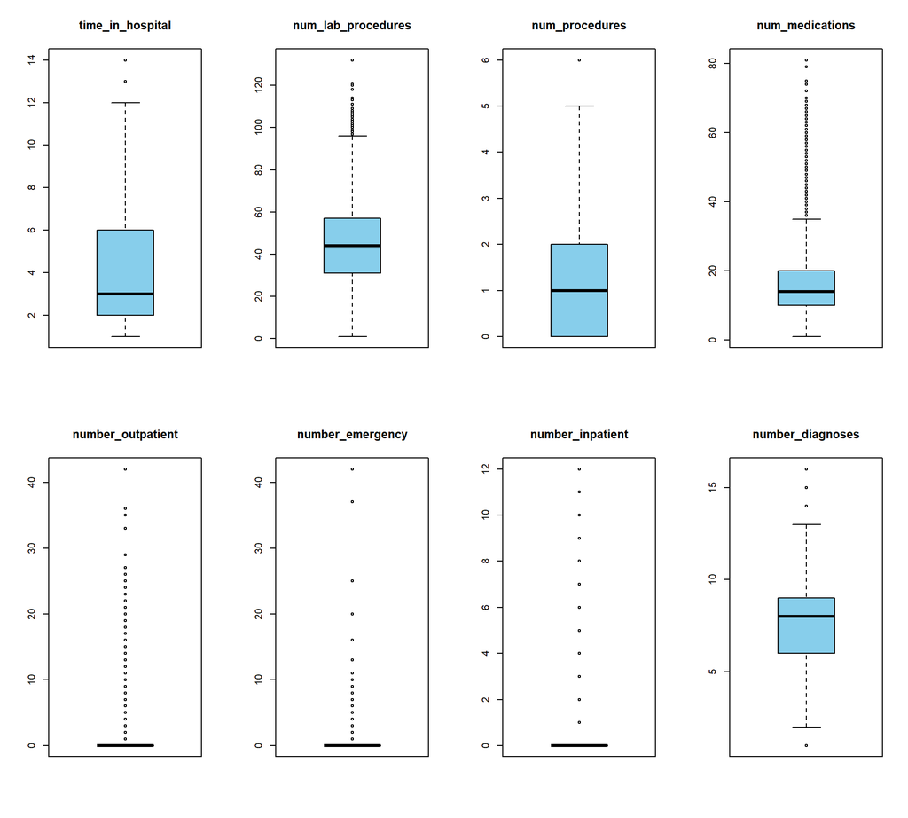

```r
par(mfrow = c(2,4))
boxplot(db1$time_in_hospital, main = "time_in_hospital",col='Sky Blue')
boxplot(db1$num_lab_procedures, main = "num_lab_procedures",col='Sky Blue')
boxplot(db1$num_procedures, main = "num_procedures",col='Sky Blue')
boxplot(db1$num_medications, main = "num_medications",col='Sky Blue')
boxplot(db1$number_outpatient, main = "number_outpatient",col='Sky Blue')
boxplot(db1$number_emergency, main = "number_emergency",col='Sky Blue')
boxplot(db1$number_inpatient, main = "number_inpatient",col='Sky Blue')
boxplot(db1$number_diagnoses, main = "number_diagnoses",col='Sky Blue')
```

```r
db2 <- remove_sd_outlier(db1, cols = "auto", n_sigmas = 3, verbose = FALSE)
```

[output not shown]

### **4.5. Exploratory Data Analysis**

```r
#creating a function to plot numerical variable
plot_histogram <- function(df,var1,var2) {
  df %>%
    ggplot(aes(x = {{var1}},fill = {{var2}})) +
    geom_histogram(alpha = 0.75,position = "stack",color = "black",bins = 30) +
    geom_vline(aes(xintercept = median({{var1}})), linetype = 2,size = 1) +
    theme(legend.position = "none")
}

plot_density <- function(df,var1,var2){
  df %>%
    ggplot(aes(x = {{var1}},fill = {{var2}})) +
    geom_density(alpha = 0.5,color = "black") +
    geom_vline(data = df %>%
                 group_by({{var2}}) %>%
                 summarize(mean.grp = mean({{var1}})),
               aes(xintercept = mean.grp,color ={{var2}}),
               linetype = "dashed",size = 1) +
    labs(caption = paste0("Lines represent average by group"),
         y = element_blank(), x = element_blank(), title = "")
    #theme(axis.ticks.y = element_blank(),axis.text.y = element_blank())
}

plot_numerical <- function(df,var1,var2) {
  p1 <- plot_histogram({{df}},{{var1}},{{var2}})
  p2 <- plot_density({{df}},{{var1}},{{var2}})

  grid.arrange(p1,p2,ncol = 2)
}
```

#### **4.5.1. Exploring Numerical Variables**

**Readmission Rate**

```r
#Creating a function to count percent to re-admissions
summarise_readm <- function(tbl) {
  tbl %>%
    summarise(readm = sum(readmitted == 1),
              n = n(),
              low = qbeta(0.025,readm + 0.5,n - readm + 0.5),
              high = qbeta(0.975,readm + 0.5,n - readm + 0.5)) %>%
              mutate(pct_readm = readm/n)
}
```

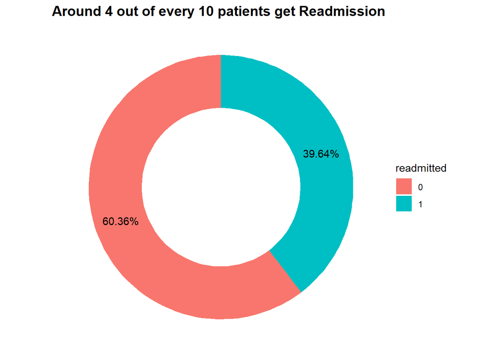

```r
db2 %>%
  group_by(readmitted) %>%
  summarise(count = n()) %>%
  mutate(freq = formattable::percent(count/sum(count))) %>%
  ggplot(aes(x = 2, y = count, fill = readmitted)) +
  geom_col() +
  geom_text(aes(label = formattable::percent(count/sum(count))),position = position_stack(vjust = 0.5)) +
  coord_polar(theta = "y") +
  xlim(c(0.2,2 + 0.5)) +
  theme_void() +
  theme(axis.title.x = element_blank(), axis.title.y = element_blank(),
        panel.border = element_blank(),panel.grid=element_blank(),
        axis.ticks = element_blank(),
        plot.title=element_text(size=14, face="bold")) +
  labs(title = "Around 4 out of every 10 patients get Readmission" )
```

#### **Age of Patients**

*Age has a higher impact on readmission?*

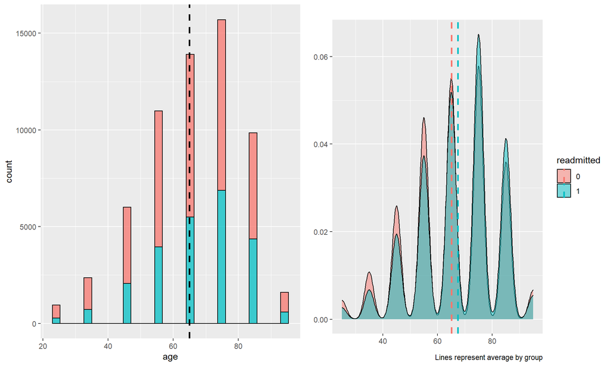

```r
plot_numerical(db2,age,readmitted)
```

As observed, Higher the age, higher will be the chance of Readmission.

`This Hypothesis is TRUE`

#### **Time Spent in Hospital**

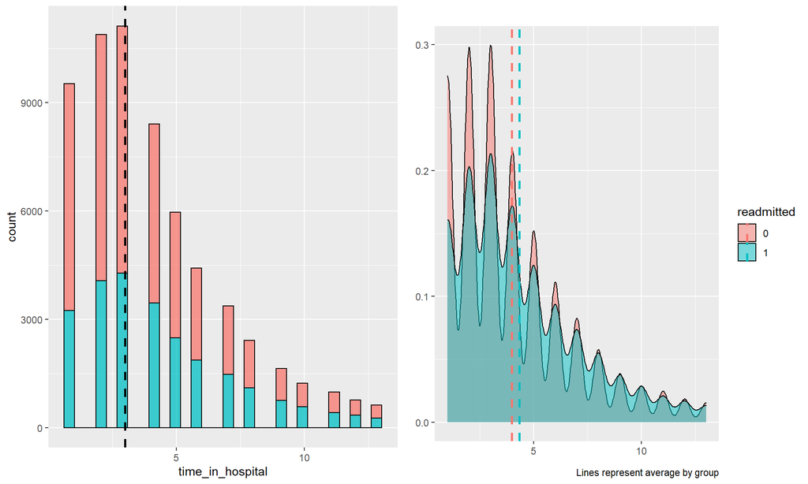

```r
plot_numerical(db2,time_in_hospital,readmitted)
```

#### **Number of Lab Tests**

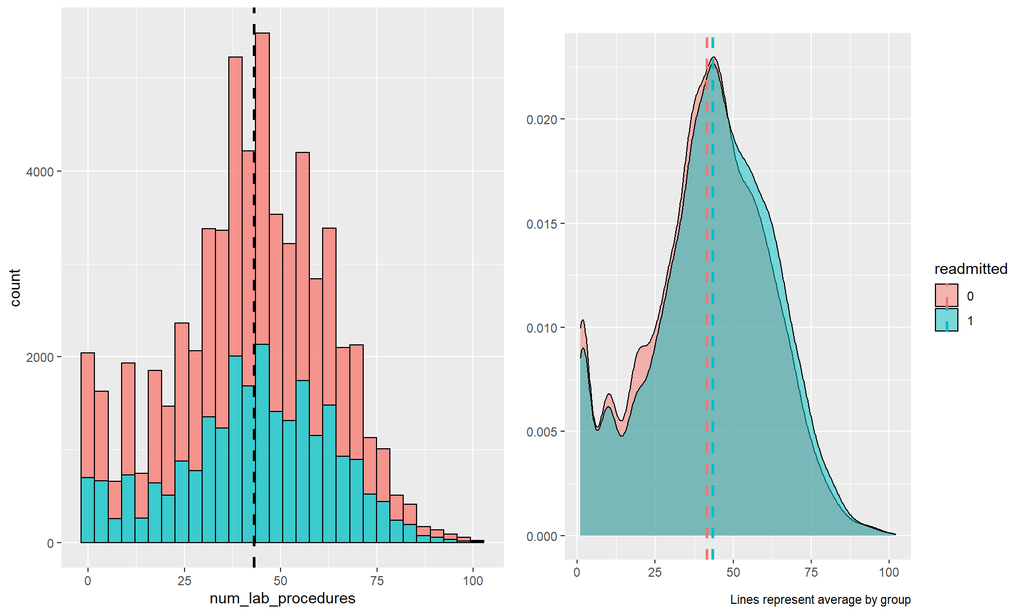

```r
plot_numerical(db2,num_lab_procedures,readmitted)
```

#### **Number of Tests (Other than lab tests)**

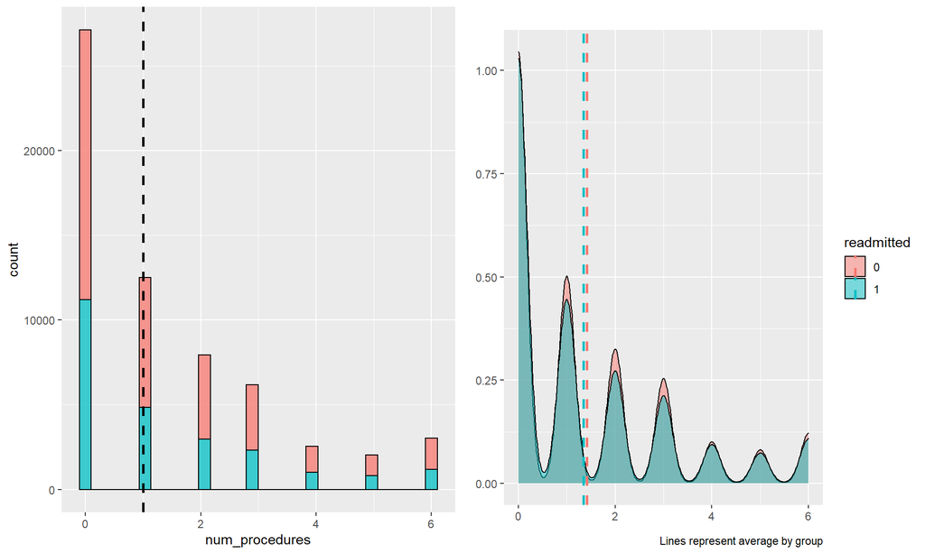

```r
plot_numerical(db2,num_procedures,readmitted)
```

#### **Number of Diagnoses**

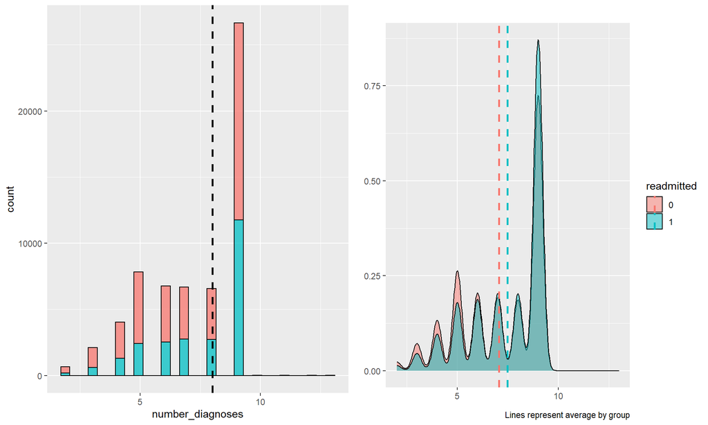

```r
plot_numerical(db2,number_diagnoses,readmitted)
```

#### **Summary Statistics of Numerical Variables**

```r
gt(ExpNumStat(db2,by="G",gp="readmitted",MesofShape=2,Outlier=FALSE,round=2))
```

| Vname | Group | TN | nNeg | nZero | nPos | NegInf | PosInf | NA_Value | Per_of_Missing | sum | min | max | mean | median | SD | CV | IQR | Skewness | Kurtosis |
| --- | --- | --- | --- | --- | --- | --- | --- | --- | --- | --- | --- | --- | --- | --- | --- | --- | --- | --- | --- |
| num_lab_procedures | readmitted:0 | 37026 | 0 | 0 | 37026 | 0 | 0 | 0 | 0 | 1534860 | 1 | 102 | 41.45 | 43 | 19.70 | 0.48 | 26 | -0.19 | -0.35 |
| num_lab_procedures | readmitted:1 | 24311 | 0 | 0 | 24311 | 0 | 0 | 0 | 0 | 1053052 | 1 | 102 | 43.32 | 44 | 19.76 | 0.46 | 25 | -0.27 | -0.32 |
| num_medications | readmitted:0 | 37026 | 0 | 0 | 37026 | 0 | 0 | 0 | 0 | 548110 | 1 | 40 | 14.80 | 14 | 7.26 | 0.49 | 9 | 0.79 | 0.51 |
| num_medications | readmitted:1 | 24311 | 0 | 0 | 24311 | 0 | 0 | 0 | 0 | 377863 | 1 | 40 | 15.54 | 15 | 7.01 | 0.45 | 10 | 0.72 | 0.42 |
| number_diagnoses | readmitted:0 | 37026 | 0 | 0 | 37026 | 0 | 0 | 0 | 0 | 261338 | 2 | 13 | 7.06 | 8 | 2.01 | 0.28 | 4 | -0.59 | -0.89 |
| number_diagnoses | readmitted:1 | 24311 | 0 | 0 | 24311 | 0 | 0 | 0 | 0 | 181789 | 2 | 13 | 7.48 | 8 | 1.85 | 0.25 | 3 | -0.93 | -0.26 |
| time_in_hospital | readmitted:0 | 37026 | 0 | 0 | 37026 | 0 | 0 | 0 | 0 | 147217 | 1 | 13 | 3.98 | 3 | 2.71 | 0.68 | 3 | 1.18 | 1.04 |
| time_in_hospital | readmitted:1 | 24311 | 0 | 0 | 24311 | 0 | 0 | 0 | 0 | 105427 | 1 | 13 | 4.34 | 4 | 2.80 | 0.65 | 4 | 1.01 | 0.51 |

#### **4.5.2. Exploring Categorical Variables**

```r
#creating a function to plot categorical variable
plot_categorical <- function(tbl,var1)
  {
  tbl %>%
    group_by({{var1}}) %>%
    summarise_readm() %>%
    mutate({{var1}} := glue("{pull(., {{var1}})}\n ({n})")) %>%
    mutate({{var1}} := fct_reorder({{var1}},desc(pct_readm))) %>%
    ggplot(aes(x = {{var1}}, y = pct_readm)) +
    geom_point(size = 4,shape = 18,aes(color = {{var1}})) +
    geom_errorbar(aes(ymin = low,ymax = high,
                      color = {{var1}}),size = 1) +
    theme(legend.position = "none") +
    geom_hline(aes(yintercept = sum(readm)/sum(n)),linetype = 3) +
    scale_y_continuous(labels = scales::percent) +
    labs(y=NULL,x=NULL)+
    coord_flip()
}
```

#### **Gender**

*Women patients are more likely to be readmitted than men?*

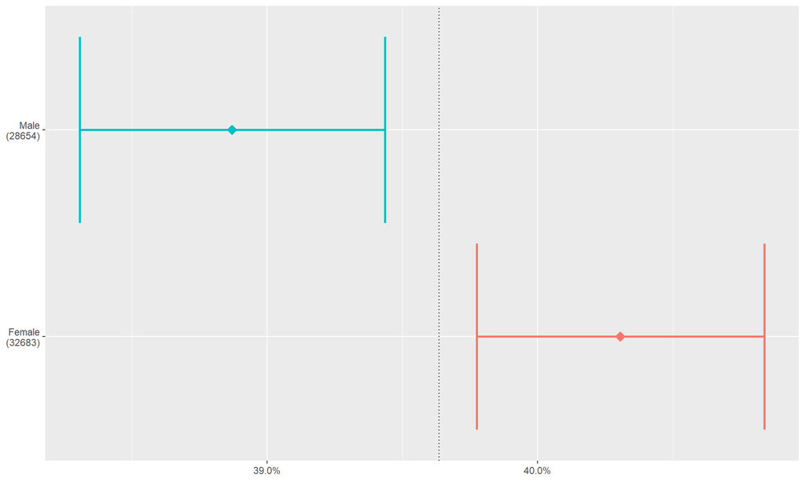

```r
plot_categorical(db2,gender)
```

As observed, Women have higher chance of being readmitted than men.

`This Hypothesis is TRUE`

#### **Race of Patients**

*African Americans are more likely to be re-admitted than other ethnic groups?*

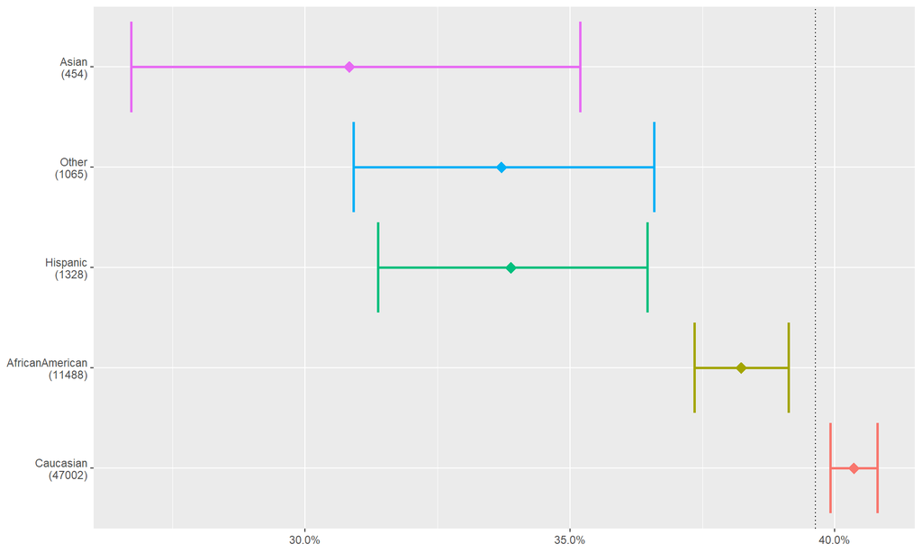

```r
plot_categorical(db2,race)
```

As observed, African Americans have relatively low chance of Readmission than the Caucasian group.

`This Hypothesis is FALSE`

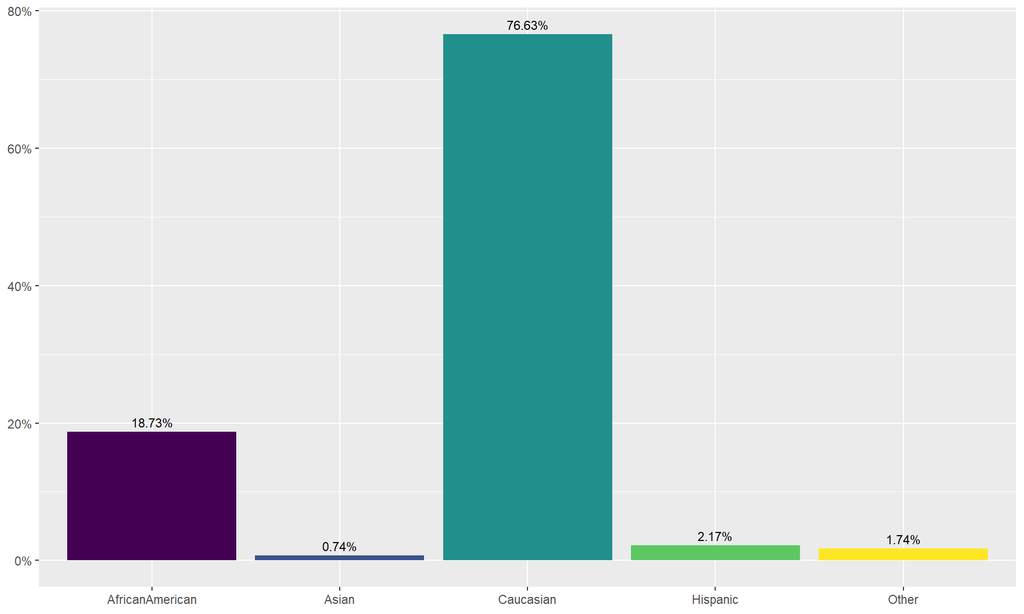

```r
ggplot(data=db2,aes(x=db2$race,y = prop.table(stat(count)),fill = db2$race,label = scales::percent(prop.table(stat(count)))))+
  geom_bar(position = "dodge") +
  scale_fill_viridis_d(option = "viridis", direction = 1) +
  geom_text(stat = 'count',position = position_dodge(.5),vjust = -0.5,hjust = 0.5,size = 3) +
  scale_y_continuous(labels = scales::percent)+
  labs(y=NULL,x=NULL)+
  theme(legend.position = "none",plot.title = element_text(size = 20, face = "bold"))
```

#### **Admission Type**

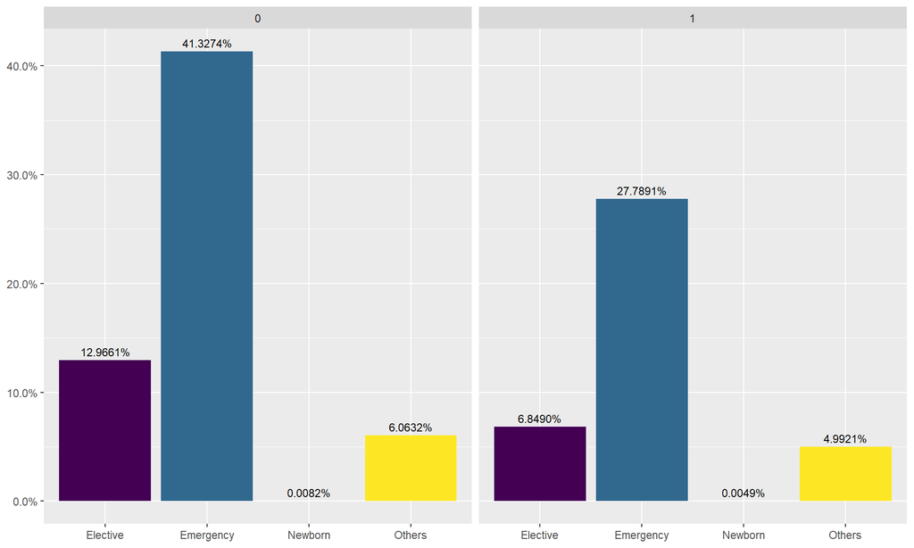

```r
ggplot(data=db2,aes(x=db2$admission_type,y = prop.table(stat(count)),fill = db2$admission_type,label = scales::percent(prop.table(stat(count)))))+
  geom_bar(position = "dodge") +
   scale_fill_viridis_d(option = "viridis", direction = 1) +
  facet_wrap(~db2$readmitted) +
  geom_text(stat = 'count',position = position_dodge(.5),vjust = -0.5,hjust = 0.5,size = 3) +
  scale_y_continuous(labels = scales::percent)+
  labs(y=NULL,x=NULL)+
  theme(legend.position = "none")
```

#### **Admission Source**

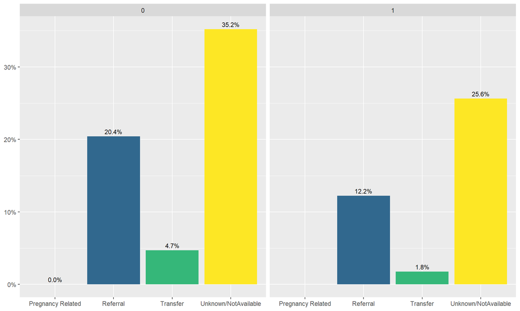

```r
ggplot(data=db2,aes(x=db2$admission_source,y = prop.table(stat(count)),fill = db2$admission_source,label = scales::percent(prop.table(stat(count)))))+
  geom_bar(position = "dodge") +
   scale_fill_viridis_d(option = "viridis", direction = 1) +
  facet_wrap(~db2$readmitted) +
  geom_text(stat = 'count',position = position_dodge(.5),vjust = -0.5,hjust = 0.5,size = 3) +
  scale_y_continuous(labels = scales::percent)+
  labs(y=NULL,x=NULL)+
  theme(legend.position = "none")
```

#### **HbA1c Result**

*Normal result of HbA1c Measurement leads to lower Hospital Readmission Rates?*

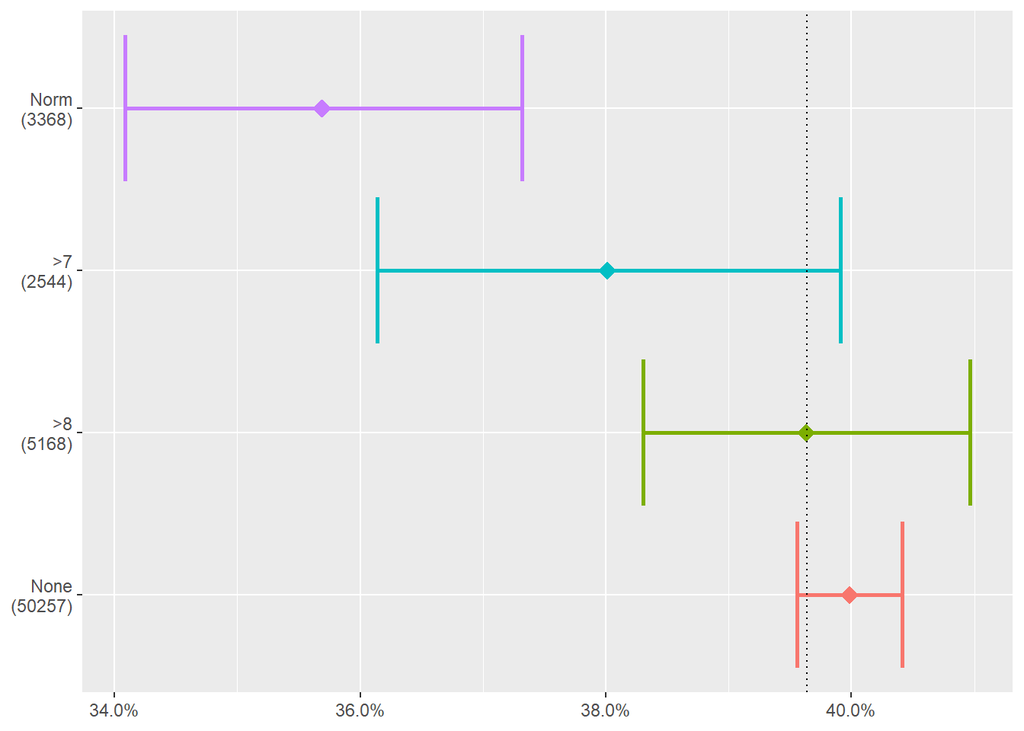

```r
plot_categorical(db2,A1Cresult)
```

Patients with no Hb1Ac obtained have higher chance of readmission than those who have obtained normal results.

`This Hypothesis is TRUE`

#### **Blood Sugar Level**

*High Blood sugar level patients have higher chance of readmission?*

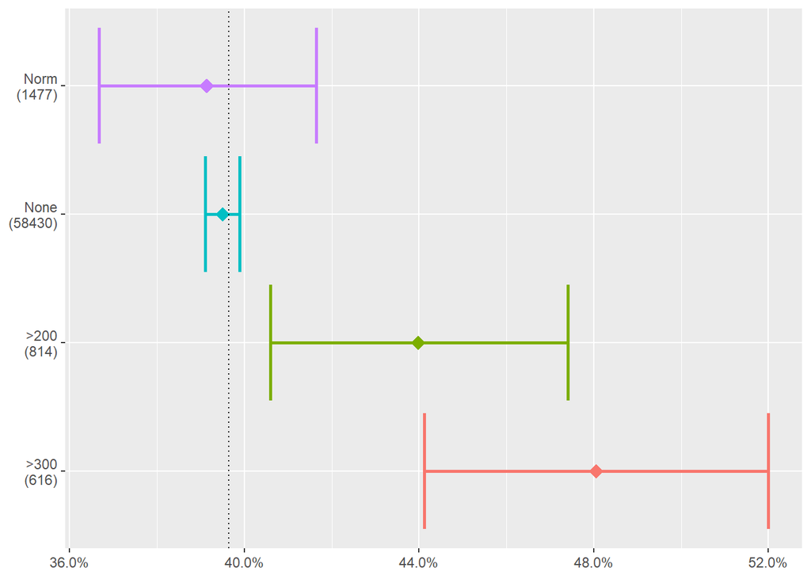

```r
plot_categorical(db2,max_glu_serum)
```

As observed, Patients with high blood sugar level have higher chance of Readmission.

`This Hypothesis is TRUE`

#### **Insulin**

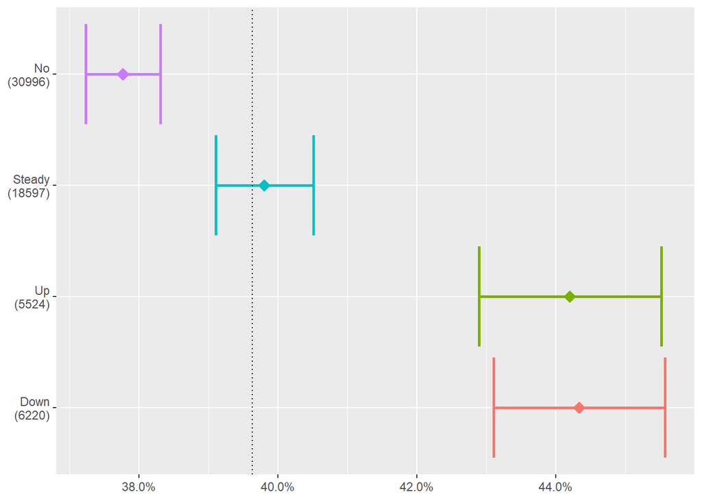

```r
plot_categorical(db2,insulin)
```

#### **Diagnosis Type**

**Primary Diagnosis**

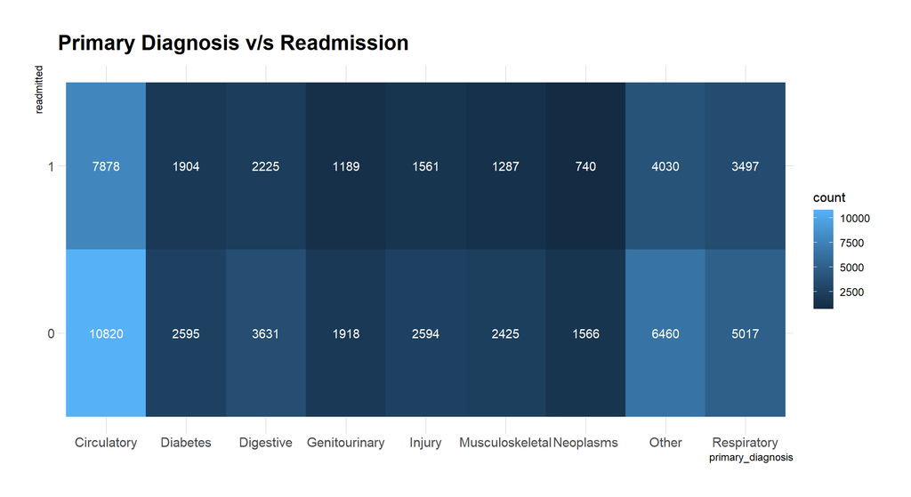

```r
db2 %>%
  group_by(primary_diagnosis,readmitted) %>%
  summarise(count = n()) %>%
  ggplot(.,mapping = aes(x=primary_diagnosis,y=readmitted,fill=count)) +
  geom_tile()+
  geom_text(aes(label=count),color="white")+
  labs(title = "Primary Diagnosis v/s Readmission") +
  theme_ipsum()
```

**Secondary Diagnosis**

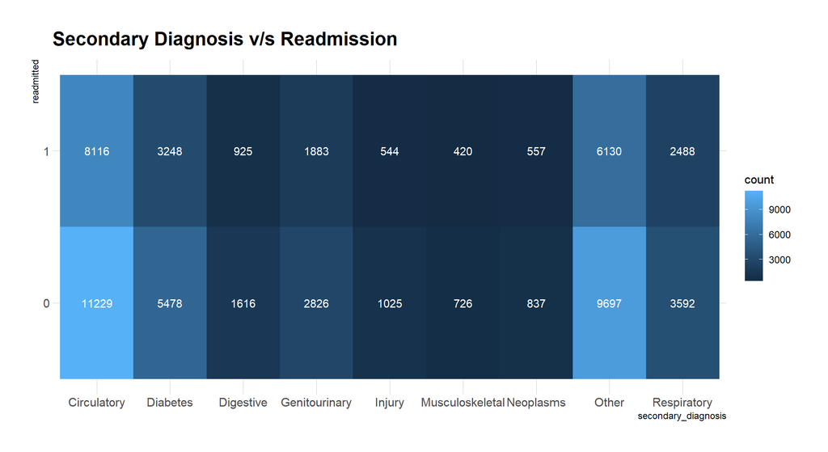

```r
db2 %>%
  group_by(secondary_diagnosis,readmitted) %>%
  summarise(count = n()) %>%
  ggplot(.,mapping = aes(x=secondary_diagnosis,y=readmitted,fill=count)) +
  geom_tile()+
  geom_text(aes(label=count),color="white")+
  labs(title = "Secondary Diagnosis v/s Readmission") +
  theme_ipsum()
```

**Additional Diagnosis**

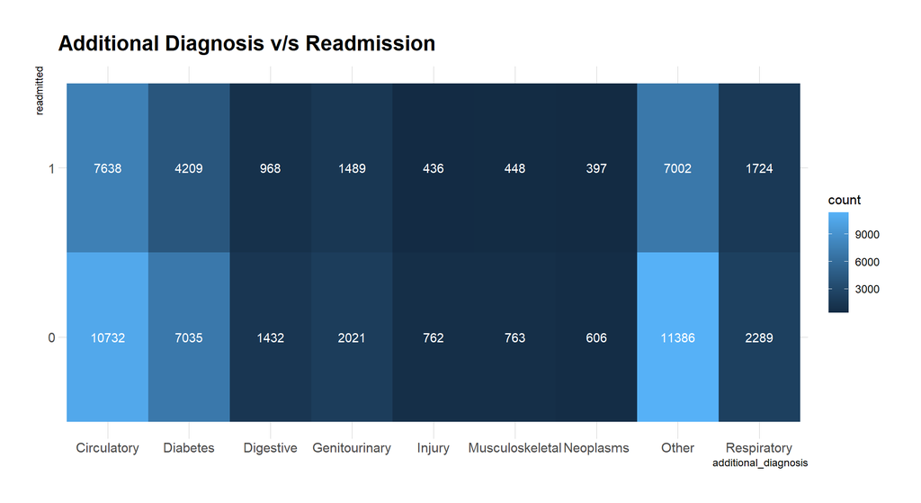

```r
db2 %>%
  group_by(additional_diagnosis,readmitted) %>%
  summarise(count = n()) %>%
  ggplot(.,mapping = aes(x=additional_diagnosis,y=readmitted,fill=count)) +
  geom_tile()+
  geom_text(aes(label=count),color="white")+
  labs(title = "Additional Diagnosis v/s Readmission") +
  theme_ipsum()
```

#### **Hypothesis Results**

| HYPOTHESIS | RESULT |
| --- | --- |
| *Age has a higher impact on readmission?* | TRUE |
| *Women patients are more likely to be re-admitted than men?* | TRUE |
| *African Americans are more likely to be re-admitted than other ethnic groups?* | FALSE |
| *Normal result of HbA1c Measurement leads to lower Hospital Readmission Rates?* | TRUE |
| *High Blood sugar level patients have higher chance of readmission?* | TRUE |

### **4.7. Check for Multicollinearity**

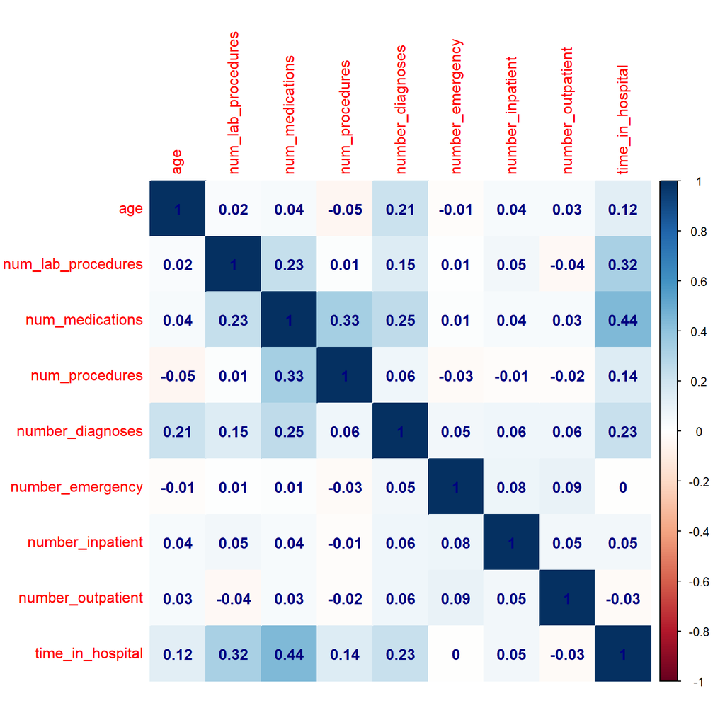

```r
corr <- db2 %>%
  select(where(is.numeric))
cor_matrix <- cor(corr)
corrplot(cor_matrix, method = 'color', order = 'alphabet',addCoef.col = "navy blue")
```

We can see that there is **No Multicollinearity** in our Data.

## **6. Model Building**

### **6.1. Feature Selection**

Boruta is a feature selection algorithm. Precisely, it works as a wrapper algorithm around Random Forest

Below is the step wise working of boruta algorithm:

1. Firstly, it adds randomness to the given data set by creating shuffled copies of all features (which are called shadow features).
2. Then, it trains a random forest classifier on the extended data set and applies a feature importance measure (the default is Mean Decrease Accuracy) to evaluate the importance of each feature where higher means more important.
3. At every iteration, it checks whether a real feature has a higher importance than the best of its shadow features (i.e. whether the feature has a higher Z score than the maximum Z score of its shadow features) and constantly removes features which are deemed highly unimportant.
4. Finally, the algorithm stops either when all features gets confirmed or rejected or it reaches a specified limit of random forest runs.

*(Source : Analytics Vidya)*

```r
set.seed(111)
boruta <- Boruta(readmitted ~ ., data = db2, doTrace = 2, maxRuns = 100)
print(boruta)
#Output
#Boruta performed 99 iterations in 5.126252 hours.
 #25 attributes confirmed important: A1Cresult, additional_diagnosis,
#admission_source, admission_type, age and 20 more;
 #14 attributes confirmed unimportant: acarbose, acetohexamide,
#chlorpropamide, glimepiride, glipizide.metformin and 9 more;
 #1 tentative attributes left: rosiglitazone;
```

**Final Features which are affecting my target are : 26**

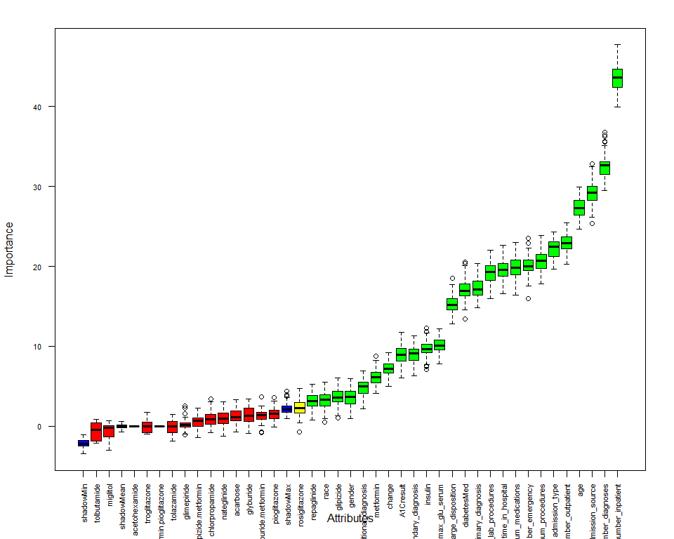

```r
plot(boruta, las = 2, cex.axis = 0.7)
attStats(boruta)
```

**Blue boxplots** correspond to minimal, average and maximum Z score of a shadow attribute. **Red, yellow and green** boxplots represent Z scores of rejected, tentative and confirmed attributes respectively.

```r
getNonRejectedFormula(boruta)
#Output
#readmitted ~ race + gender + age + admission_type + discharge_disposition + admission_source + time_in_hospital + num_lab_procedures + num_procedures + num_medications + number_outpatient + number_emergency + number_inpatient + number_diagnoses + max_glu_serum + A1Cresult + metformin + repaglinide + glipizide + rosiglitazone + insulin + change + diabetesMed + primary_diagnosis + secondary_diagnosis + additional_diagnosis
```

**Variable Importance**

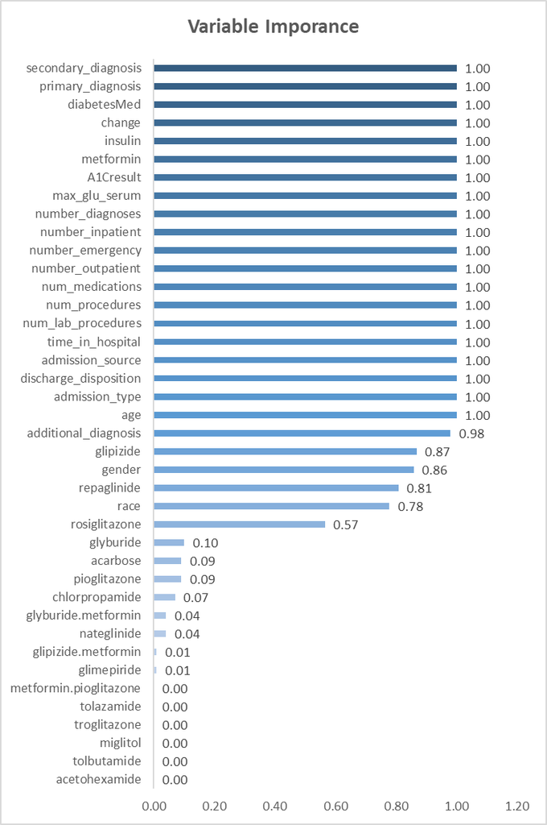

### **6.2. Preparation of final Dataset**

Only Keeping that feature which were selected by boruta algorithm

```r
final_df = select(db2,-19:-22,-24:-26,-28:-31,-33:-35)
```

Spliting Data into Training Set and Validation Set

```r
set.seed(2022)
trainIndex1 <- createDataPartition(final_df$readmitted,p=0.70,list=FALSE)
#splitting data into training/testing data using the trainIndex object
TRAIN <- final_df[trainIndex1,] #training data (70% of data)
TEST <- final_df[-trainIndex1,] #testing data (30% of data)
```

### **6.3. Data Balancing**

Imbalanced classification is a supervised learning problem where one class outnumbers other class by a large proportion. This problem is faced more frequently in binary classification problems than multi-level classification problems.

**Random oversampling** balances the data by randomly oversampling the minority class.

```r
data_rose <- ROSE(readmitted ~., data = TRAIN)$data
table(data_rose$readmitted)
```

```
##
##     0     1
## 21418 21519
```

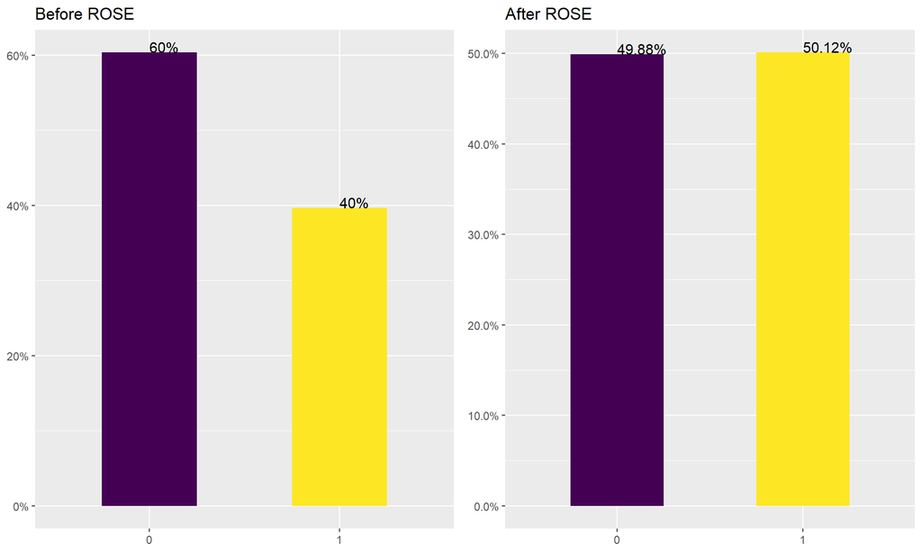

```r
r1 <- ggplot(TRAIN,mapping = aes(x=readmitted,y = prop.table(stat(count)),fill = readmitted,label = scales::percent(prop.table(stat(count)))))+
  geom_bar(position = "dodge",width = .5) +
  scale_fill_viridis_d(option = "viridis", direction = 1) +
  geom_text(stat = 'count',position = position_dodge(1),vjust = 0,hjust = 0,size = 4) +
  scale_y_continuous(labels = scales::percent)+
  labs(title = "Before ROSE",x=NULL,y=NULL)+
  theme(legend.position = "none")

r2 <- ggplot(data_rose,mapping = aes(x=readmitted,y = prop.table(stat(count)),fill = readmitted,label = scales::percent(prop.table(stat(count)))))+
  geom_bar(position = "dodge",width = .5) +
  scale_fill_viridis_d(option = "viridis", direction = 1) +
  geom_text(stat = 'count',position = position_dodge(1),vjust = 0,hjust = 0,size = 4) +
  scale_y_continuous(labels = scales::percent)+
  labs(title = "After ROSE",x=NULL,y=NULL)+
  theme(legend.position = "none"
)
grid.arrange(r1,r2, ncol = 2, nrow = 1)
```

### **6.4 Model Building**

#### **6.4.1. Model 1**

```r
logitMod1 <- glm(readmitted ~ race + gender + age + admission_type + discharge_disposition + admission_source + time_in_hospital + num_lab_procedures + num_procedures + num_medications + number_outpatient + number_emergency + number_inpatient + number_diagnoses + max_glu_serum + A1Cresult + metformin + repaglinide + glipizide + rosiglitazone + insulin + change + diabetesMed + primary_diagnosis + secondary_diagnosis + additional_diagnosis ,data = data_rose,family = binomial)
summ(logitMod1,vifs = TRUE)
```

| Observations | 42937 |
| --- | --- |
| Dependent variable | readmitted |
| Type | Generalized linear model |
| Family | binomial |
| Link | logit |

| χ²(72) | 2169.99 |
| --- | --- |
| Pseudo-R² (Cragg-Uhler) | 0.07 |
| Pseudo-R² (McFadden) | 0.04 |
| AIC | 57499.10 |
| BIC | 58131.82 |

|  | Est. | S.E. | z val. | p | VIF |
| --- | --- | --- | --- | --- | --- |
| (Intercept) | -13.24 | 59.41 | -0.22 | 0.82 | NA |
| raceAsian | -0.64 | 0.13 | -5.11 | 0.00 | 1.09 |
| raceCaucasian | 0.01 | 0.03 | 0.28 | 0.78 | 1.09 |
| raceHispanic | -0.19 | 0.07 | -2.62 | 0.01 | 1.09 |
| raceOther | -0.22 | 0.08 | -2.78 | 0.01 | 1.09 |
| genderMale | -0.06 | 0.02 | -3.17 | 0.00 | 1.04 |
| age | 0.01 | 0.00 | 9.09 | 0.00 | 1.26 |
| admission_typeEmergency | 0.17 | 0.03 | 5.07 | 0.00 | 2.44 |
| admission_typeNewborn | 0.21 | 1.00 | 0.21 | 0.83 | 2.44 |
| admission_typeOthers | 0.40 | 0.05 | 8.80 | 0.00 | 2.44 |
| discharge_dispositionDischarged | 0.51 | 1.23 | 0.42 | 0.68 | 1.37 |
| discharge_dispositionLeft | 0.57 | 1.23 | 0.46 | 0.64 | 1.37 |
| discharge_dispositionOutpatient | 11.17 | 119.47 | 0.09 | 0.93 | 1.37 |
| discharge_dispositionTransferred | 0.73 | 1.23 | 0.59 | 0.56 | 1.37 |
| discharge_dispositionUnknown/NotAvailable | 0.50 | 1.24 | 0.41 | 0.68 | 1.37 |
| admission_sourceReferral | 10.27 | 59.39 | 0.17 | 0.86 | 1.80 |
| admission_sourceTransfer | 9.60 | 59.39 | 0.16 | 0.87 | 1.80 |
| admission_sourceUnknown/NotAvailable | 10.23 | 59.39 | 0.17 | 0.86 | 1.80 |
| time_in_hospital | 0.02 | 0.00 | 5.91 | 0.00 | 1.38 |
| num_lab_procedures | 0.00 | 0.00 | 3.43 | 0.00 | 1.30 |
| num_procedures | -0.02 | 0.01 | -3.93 | 0.00 | 1.28 |
| num_medications | 0.00 | 0.00 | 2.42 | 0.02 | 1.52 |
| number_outpatient | 0.14 | 0.02 | 8.57 | 0.00 | 1.03 |
| number_emergency | 0.35 | 0.04 | 8.54 | 0.00 | 1.02 |
| number_inpatient | 0.53 | 0.03 | 15.83 | 0.00 | 1.02 |
| number_diagnoses | 0.06 | 0.01 | 10.42 | 0.00 | 1.31 |
| max_glu_serum>300 | 0.08 | 0.13 | 0.60 | 0.55 | 1.47 |
| max_glu_serumNone | 0.17 | 0.09 | 1.91 | 0.06 | 1.47 |
| max_glu_serumNorm | -0.01 | 0.11 | -0.13 | 0.90 | 1.47 |
| A1Cresult>8 | 0.11 | 0.06 | 1.76 | 0.08 | 1.19 |
| A1CresultNone | 0.19 | 0.05 | 3.80 | 0.00 | 1.19 |
| A1CresultNorm | -0.06 | 0.06 | -0.98 | 0.33 | 1.19 |
| metforminNo | 0.22 | 0.13 | 1.71 | 0.09 | 1.49 |
| metforminSteady | 0.08 | 0.13 | 0.64 | 0.52 | 1.49 |
| metforminUp | 0.24 | 0.16 | 1.51 | 0.13 | 1.49 |
| repaglinideNo | 0.20 | 0.45 | 0.44 | 0.66 | 1.03 |
| repaglinideSteady | 0.42 | 0.46 | 0.92 | 0.36 | 1.03 |
| repaglinideUp | 0.09 | 0.59 | 0.16 | 0.87 | 1.03 |
| glipizideNo | -0.01 | 0.14 | -0.07 | 0.94 | 1.20 |
| glipizideSteady | 0.04 | 0.14 | 0.28 | 0.78 | 1.20 |
| glipizideUp | 0.06 | 0.18 | 0.32 | 0.75 | 1.20 |
| rosiglitazoneNo | 0.61 | 0.36 | 1.72 | 0.09 | 1.11 |
| rosiglitazoneSteady | 0.84 | 0.36 | 2.34 | 0.02 | 1.11 |
| rosiglitazoneUp | 0.76 | 0.42 | 1.83 | 0.07 | 1.11 |
| insulinNo | -0.12 | 0.05 | -2.52 | 0.01 | 2.92 |
| insulinSteady | -0.15 | 0.04 | -3.78 | 0.00 | 2.92 |
| insulinUp | -0.09 | 0.04 | -1.94 | 0.05 | 2.92 |
| changeNo | 0.01 | 0.03 | 0.32 | 0.75 | 2.50 |
| diabetesMedYes | 0.27 | 0.03 | 8.43 | 0.00 | 1.93 |
| primary_diagnosisDiabetes | 0.13 | 0.05 | 2.93 | 0.00 | 2.60 |
| primary_diagnosisDigestive | -0.06 | 0.04 | -1.60 | 0.11 | 2.60 |
| primary_diagnosisGenitourinary | -0.15 | 0.05 | -3.07 | 0.00 | 2.60 |
| primary_diagnosisInjury | -0.17 | 0.04 | -3.85 | 0.00 | 2.60 |
| primary_diagnosisMusculoskeletal | -0.25 | 0.05 | -5.20 | 0.00 | 2.60 |
| primary_diagnosisNeoplasms | -0.41 | 0.06 | -6.83 | 0.00 | 2.60 |
| primary_diagnosisOther | -0.12 | 0.03 | -3.65 | 0.00 | 2.60 |
| primary_diagnosisRespiratory | -0.11 | 0.03 | -3.32 | 0.00 | 2.60 |
| secondary_diagnosisDiabetes | 0.01 | 0.04 | 0.36 | 0.72 | 2.14 |
| secondary_diagnosisDigestive | -0.18 | 0.06 | -3.16 | 0.00 | 2.14 |
| secondary_diagnosisGenitourinary | -0.14 | 0.04 | -3.32 | 0.00 | 2.14 |
| secondary_diagnosisInjury | -0.31 | 0.07 | -4.55 | 0.00 | 2.14 |
| secondary_diagnosisMusculoskeletal | -0.14 | 0.08 | -1.85 | 0.06 | 2.14 |
| secondary_diagnosisNeoplasms | 0.16 | 0.07 | 2.16 | 0.03 | 2.14 |
| secondary_diagnosisOther | -0.09 | 0.03 | -3.20 | 0.00 | 2.14 |
| secondary_diagnosisRespiratory | -0.10 | 0.04 | -2.68 | 0.01 | 2.14 |
| additional_diagnosisDiabetes | -0.06 | 0.03 | -1.85 | 0.06 | 1.56 |
| additional_diagnosisDigestive | 0.03 | 0.05 | 0.64 | 0.52 | 1.56 |
| additional_diagnosisGenitourinary | -0.03 | 0.05 | -0.72 | 0.47 | 1.56 |
| additional_diagnosisInjury | -0.34 | 0.08 | -4.49 | 0.00 | 1.56 |
| additional_diagnosisMusculoskeletal | -0.21 | 0.08 | -2.75 | 0.01 | 1.56 |
| additional_diagnosisNeoplasms | -0.14 | 0.08 | -1.68 | 0.09 | 1.56 |
| additional_diagnosisOther | -0.15 | 0.03 | -5.66 | 0.00 | 1.56 |
| additional_diagnosisRespiratory | -0.05 | 0.04 | -1.12 | 0.26 | 1.56 |

Standard errors: MLE

```r
logit_pred1 <- predict(logitMod1, TEST,type = "response")
pred1 <- ifelse(logit_pred1 >= 0.5, 1, 0)
```

```r
cm1 <- confusionMatrix(factor(pred1), factor(TEST$readmitted),positive = "1")
```

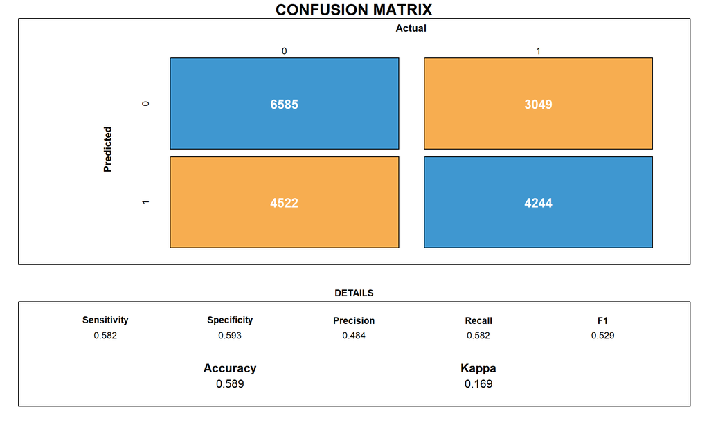

```r
draw_confusion_matrix(cm1)
```

```r
AUC(logit_pred1,TEST$readmitted)
```

```
## [1] 0.6215771
```

**58.9% Accuracy and 62.1% AUC**

#### **6.4.2. Model 2**

Removed statistically Insignificant variables from the previous model to check if there is any improvement.

```r
logitMod2 <- glm(readmitted ~ race + gender + age + admission_type +  time_in_hospital + num_lab_procedures + num_procedures + num_medications + number_outpatient + number_emergency + number_inpatient + number_diagnoses + A1Cresult + rosiglitazone + insulin + change + diabetesMed + primary_diagnosis + secondary_diagnosis + additional_diagnosis,data = data_rose,family = binomial)
summ(logitMod2,vifs = TRUE)
```

| Observations | 42937 |
| --- | --- |
| Dependent variable | readmitted |
| Type | Generalized linear model |
| Family | binomial |
| Link | logit |

| χ²(52) | 1830.75 |
| --- | --- |
| Pseudo-R² (Cragg-Uhler) | 0.06 |
| Pseudo-R² (McFadden) | 0.03 |
| AIC | 57798.33 |
| BIC | 58257.71 |

|  | Est. | S.E. | z val. | p | VIF |
| --- | --- | --- | --- | --- | --- |
| (Intercept) | -1.99 | 0.37 | -5.42 | 0.00 | NA |
| raceAsian | -0.63 | 0.12 | -5.08 | 0.00 | 1.08 |
| raceCaucasian | 0.01 | 0.03 | 0.49 | 0.63 | 1.08 |
| raceHispanic | -0.17 | 0.07 | -2.41 | 0.02 | 1.08 |
| raceOther | -0.20 | 0.08 | -2.50 | 0.01 | 1.08 |
| genderMale | -0.06 | 0.02 | -3.06 | 0.00 | 1.03 |
| age | 0.01 | 0.00 | 10.46 | 0.00 | 1.17 |
| admission_typeEmergency | 0.14 | 0.03 | 5.01 | 0.00 | 1.28 |
| admission_typeNewborn | -0.51 | 0.93 | -0.55 | 0.58 | 1.28 |
| admission_typeOthers | 0.36 | 0.04 | 9.40 | 0.00 | 1.28 |
| time_in_hospital | 0.02 | 0.00 | 6.01 | 0.00 | 1.29 |
| num_lab_procedures | 0.00 | 0.00 | 3.79 | 0.00 | 1.26 |
| num_procedures | -0.03 | 0.01 | -4.90 | 0.00 | 1.26 |
| num_medications | 0.00 | 0.00 | 3.05 | 0.00 | 1.50 |
| number_outpatient | 0.15 | 0.02 | 9.22 | 0.00 | 1.03 |
| number_emergency | 0.36 | 0.04 | 8.88 | 0.00 | 1.01 |
| number_inpatient | 0.52 | 0.03 | 15.73 | 0.00 | 1.01 |
| number_diagnoses | 0.07 | 0.01 | 12.63 | 0.00 | 1.28 |
| A1Cresult>8 | 0.10 | 0.06 | 1.76 | 0.08 | 1.17 |
| A1CresultNone | 0.19 | 0.05 | 3.85 | 0.00 | 1.17 |
| A1CresultNorm | -0.06 | 0.06 | -0.93 | 0.35 | 1.17 |
| rosiglitazoneNo | 0.60 | 0.35 | 1.69 | 0.09 | 1.10 |
| rosiglitazoneSteady | 0.83 | 0.36 | 2.33 | 0.02 | 1.10 |
| rosiglitazoneUp | 0.66 | 0.42 | 1.58 | 0.11 | 1.10 |
| insulinNo | -0.17 | 0.04 | -4.18 | 0.00 | 2.19 |
| insulinSteady | -0.20 | 0.04 | -5.20 | 0.00 | 2.19 |
| insulinUp | -0.08 | 0.04 | -1.74 | 0.08 | 2.19 |
| changeNo | 0.04 | 0.03 | 1.56 | 0.12 | 1.93 |
| diabetesMedYes | 0.24 | 0.03 | 8.08 | 0.00 | 1.69 |
| primary_diagnosisDiabetes | 0.15 | 0.04 | 3.40 | 0.00 | 2.40 |
| primary_diagnosisDigestive | -0.07 | 0.04 | -1.69 | 0.09 | 2.40 |
| primary_diagnosisGenitourinary | -0.15 | 0.05 | -2.97 | 0.00 | 2.40 |
| primary_diagnosisInjury | -0.14 | 0.04 | -3.12 | 0.00 | 2.40 |
| primary_diagnosisMusculoskeletal | -0.19 | 0.05 | -3.92 | 0.00 | 2.40 |
| primary_diagnosisNeoplasms | -0.36 | 0.06 | -6.16 | 0.00 | 2.40 |
| primary_diagnosisOther | -0.12 | 0.03 | -3.60 | 0.00 | 2.40 |
| primary_diagnosisRespiratory | -0.12 | 0.03 | -3.54 | 0.00 | 2.40 |
| secondary_diagnosisDiabetes | 0.03 | 0.04 | 0.98 | 0.33 | 2.10 |
| secondary_diagnosisDigestive | -0.17 | 0.06 | -3.01 | 0.00 | 2.10 |
| secondary_diagnosisGenitourinary | -0.13 | 0.04 | -3.08 | 0.00 | 2.10 |
| secondary_diagnosisInjury | -0.31 | 0.07 | -4.57 | 0.00 | 2.10 |
| secondary_diagnosisMusculoskeletal | -0.15 | 0.08 | -2.00 | 0.05 | 2.10 |
| secondary_diagnosisNeoplasms | 0.17 | 0.07 | 2.25 | 0.02 | 2.10 |
| secondary_diagnosisOther | -0.08 | 0.03 | -2.89 | 0.00 | 2.10 |
| secondary_diagnosisRespiratory | -0.10 | 0.04 | -2.61 | 0.01 | 2.10 |
| additional_diagnosisDiabetes | -0.05 | 0.03 | -1.49 | 0.14 | 1.54 |
| additional_diagnosisDigestive | 0.04 | 0.05 | 0.74 | 0.46 | 1.54 |
| additional_diagnosisGenitourinary | -0.02 | 0.05 | -0.43 | 0.66 | 1.54 |
| additional_diagnosisInjury | -0.33 | 0.07 | -4.37 | 0.00 | 1.54 |
| additional_diagnosisMusculoskeletal | -0.20 | 0.08 | -2.59 | 0.01 | 1.54 |
| additional_diagnosisNeoplasms | -0.13 | 0.08 | -1.53 | 0.13 | 1.54 |
| additional_diagnosisOther | -0.14 | 0.03 | -5.46 | 0.00 | 1.54 |
| additional_diagnosisRespiratory | -0.05 | 0.04 | -1.19 | 0.23 | 1.54 |

Standard errors: MLE

```r
logit_pred2 <- predict(logitMod2, TEST,type = "response")
pred2 <- ifelse(logit_pred2 >= 0.5, 1, 0)
```

```r
cm2 <- confusionMatrix(factor(pred2), factor(TEST$readmitted),positive = "1")
```

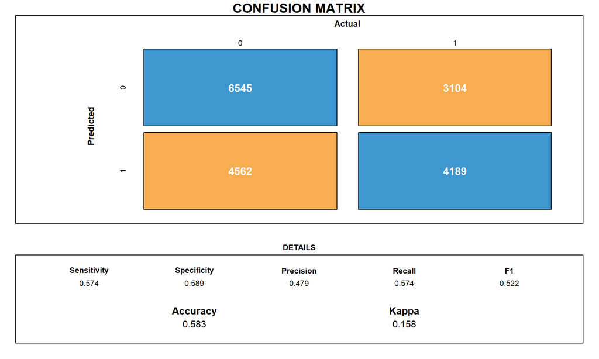

```r
draw_confusion_matrix(cm2)
```

```r
AUC(logit_pred2,TEST$readmitted)
```

```
## [1] 0.6147122
```

**58.3% Accuracy and 61.5% AUC**

#### **6.4.3. ROC Curve**

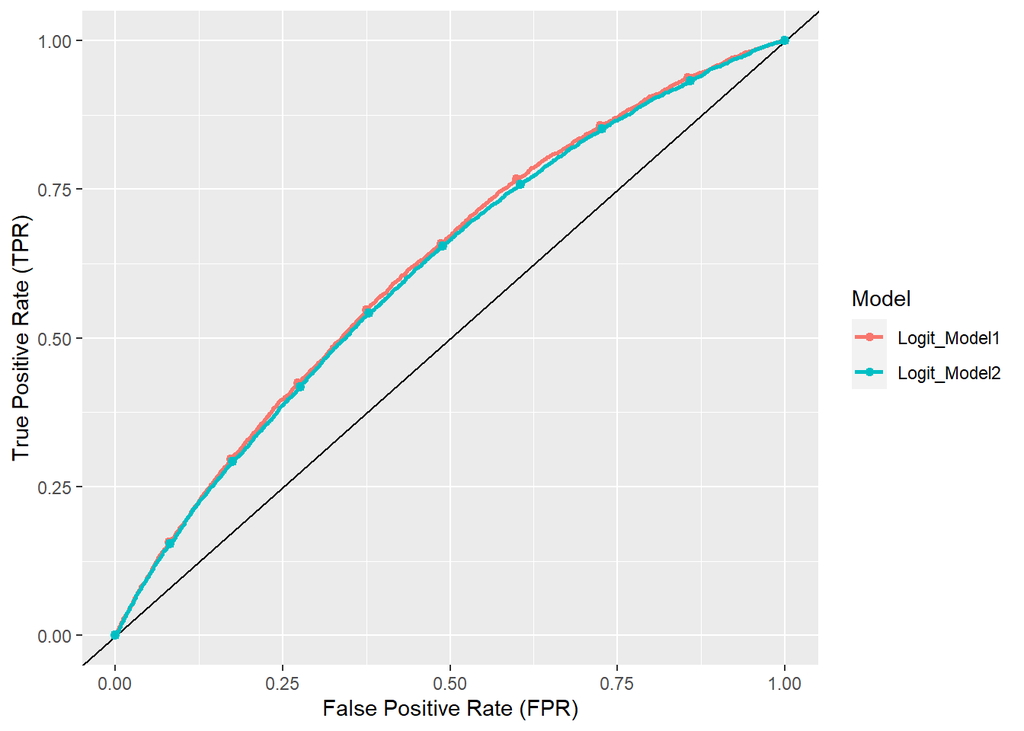

```r
plotdata.test <- data.frame(cbind(TEST$readmitted,
                                  logit_pred1,
                                  logit_pred2))
names(plotdata.test) <- c("Readmitted", "Model1", "Model2")

comparison.plot <- ggplot(plotdata.test, aes(m = Model1, d = Readmitted))+
  geom_roc(labels=FALSE, aes(color = 'Logit_Model1')) +
  labs(x = "False Positive Rate (FPR)", y = "True Positive Rate (TPR)") + geom_abline() +
  scale_color_discrete(name = 'Model') +
  geom_roc(data = plotdata.test, labels = FALSE, aes(m = Model2, d = Readmitted, color = 'Logit_Model2'))
comparison.plot
```

## **7. Conclusion**

We saw that when we removed some of the statistically insignificant variables from our first model, the **Accuracy** of model dropped from **58.9% to 58.3%** and the **AUC** also got decreased from **62.1% to 61.5%**. Therefore we consider our 1st model to be the best model.

This Model can provide doctors with updates on patients and predict which patient is more likely to readmit.

Hospital re-admissions are expensive and avoiding them is still a major challenge. It also creates a financial burden on patients and their families. Also, In US,the legislation penalises those hospitals with high readmission rate. These are the reasons why reducing readmission rate becomes necessity.